# ggfortify

ggdistribution Plot distribution

#### Description

Plot distribution

#### Usage

```
 ggdistribution(func, x, p = NULL, colour = “#000000”, linetype = NULL, fill = NULL, alpha = NULL, …)
```

#### Arguments

func PDF or CDF function x Numeric vector to be passed to func p ggplot2::ggplot instance to plot colour Line colour linetype Line type fill Fill colour alpha Alpha … Keywords passed to PDC/CDF func Value ggplot

#### Examples

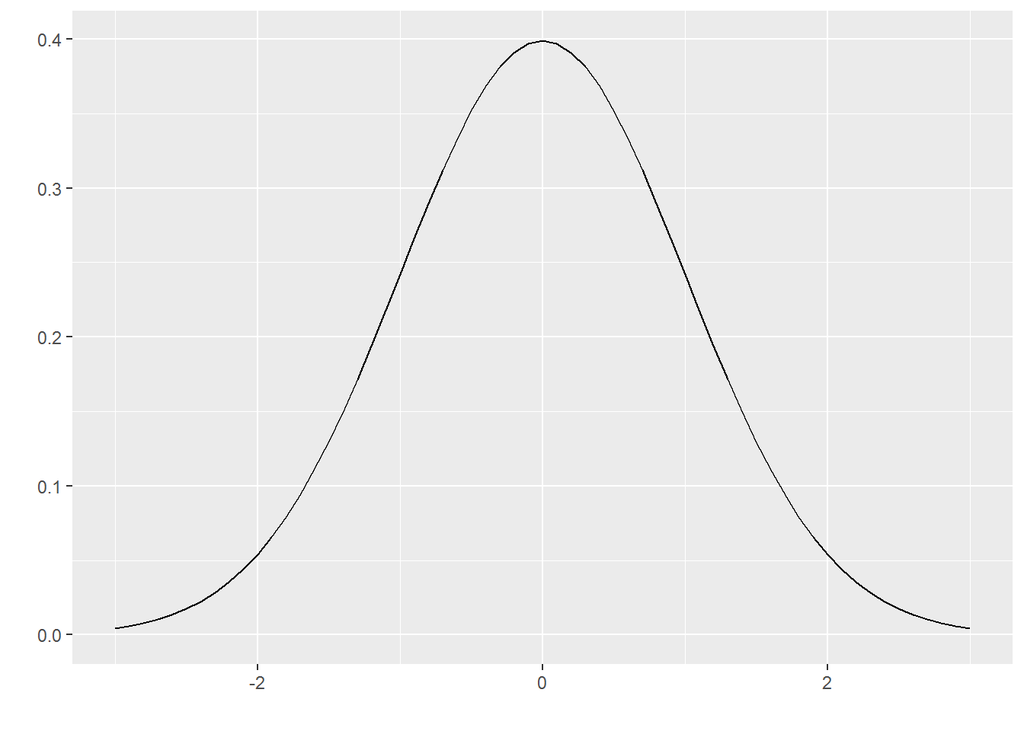

```r
ggdistribution(dnorm, seq(-3, 3, 0.1), mean = 0, sd = 1)
```

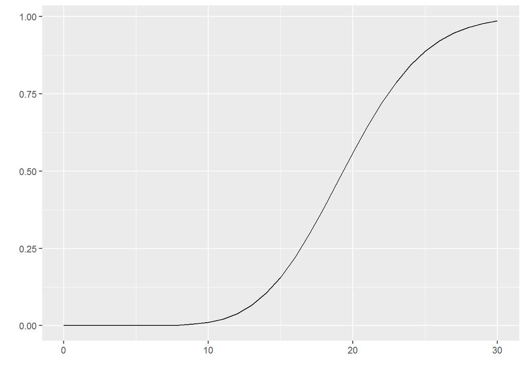

```r
ggdistribution(ppois, seq(0, 30), lambda = 20)
```

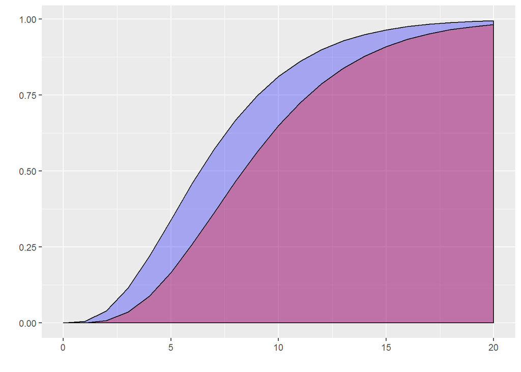

```r
p <- ggdistribution(pchisq, 0:20, df = 7, fill = 'blue')
ggdistribution(pchisq, 0:20, p = p, df = 9, fill = 'red')
```

#### Description

Plot seasonal subseries of time series, generalization of stats::monthplot

#### Usage

```
ggfreqplot(data, freq = NULL, nrow = NULL, ncol = NULL,
conf.int = FALSE, conf.int.colour = "#0000FF",
conf.int.linetype = "dashed", conf.int.fill = NULL,
conf.int.alpha = 0.3, conf.int.value = 0.95, facet.labeller = NULL, ...)
```

#### Examples

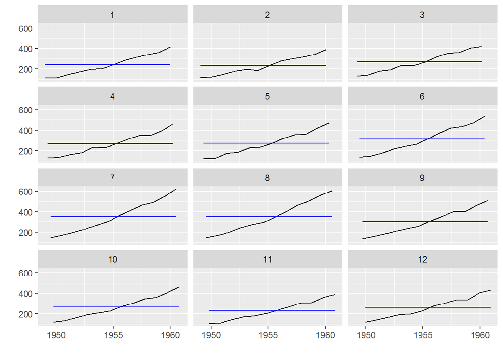

```r
ggfreqplot(AirPassengers)
```

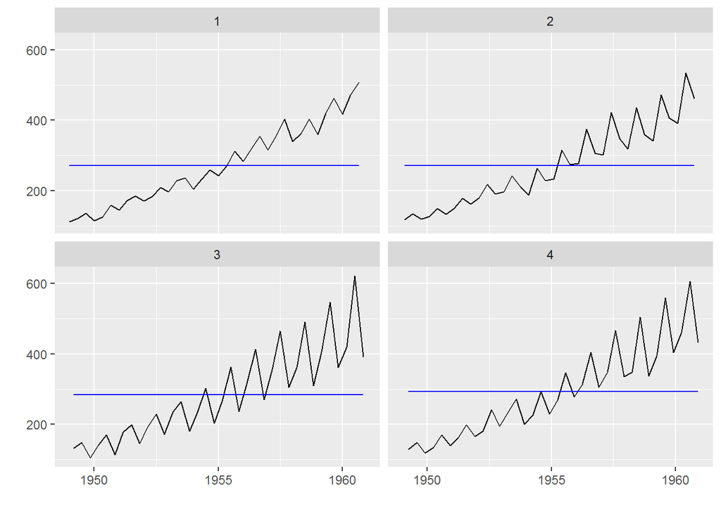

```r
ggfreqplot(AirPassengers, freq = 4)
```

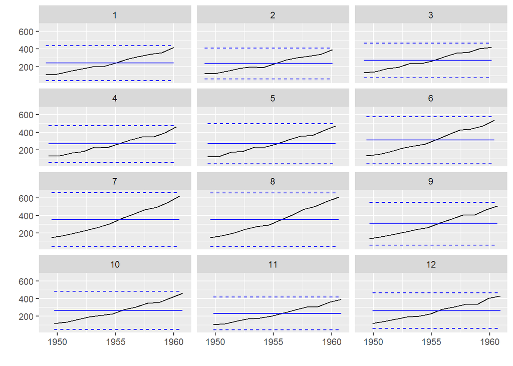

```r
ggfreqplot(AirPassengers, conf.int = TRUE)
```

ggmultiplot-class An S4 class to hold multiple ggplot2::ggplot instances

#### Description

An S4 class to hold multiple ggplot2::ggplot instances

#### Usage

```
## S4 method for signature 'ggmultiplot'
length(x)
## S4 method for signature 'ggmultiplot,ANY,ANY,ANY'
x[i, j, ..., drop = TRUE]
## S4 method for signature 'ggmultiplot'
x[[i, j, ..., drop]]
## S4 replacement method for signature 'ggmultiplot'
x[i, j, ...] <- value
## S4 replacement method for signature 'ggmultiplot'
x[[i, j, ...]] <- value
```

#### Description

Plots time-series diagnostics

#### Usage

```
ggtsdiag(object, gof.lag = 10, conf.int = TRUE,
conf.int.colour = "#0000FF", conf.int.linetype = "dashed",
conf.int.fill = NULL, conf.int.alpha = 0.3, ad.colour = "#888888",
ad.linetype = "dashed", ad.size = 0.2, nrow = NULL, ncol = 1, ...)
```

#### Arguments

- `object`: A fitted time-series model
- `gof.lag`: The maximum number of lags for a Portmanteau goodness-of-fit test
- `conf.int`: Logical flag indicating whether to plot confidence intervals
- `conf.int.colour`: line colour for confidence intervals
- `conf.int.linetype`: line type for confidence intervals
- `conf.int.fill`: fill colour for confidence intervals
- `conf.int.alpha`: alpha for confidence intervals
- `ad.colour`: Line colour for additional lines
- `ad.linetype`: Line type for additional lines
- `ad.size`: Fill colour for additional lines
- `nrow`: Number of facet/subplot rows
- `ncol`: Number of facet/subplot columns
- `...`: other keywords

Value ggplot

#### Description

The implemented grid.draw method for ggmultiplot, in order to work with ggsave() properly

#### Usage

```
## S3 method for class 'ggmultiplot'
grid.draw(plot)
```

#### Description

Infer class name

#### Usage

```
infer(data)
```

#### Description

Check if Validates number of ts variates

#### Usage

```
is.univariate(data, raise = TRUE)
```

#### Arguments

data ts instance raise Logical flag whether raise an error Value logical

#### Examples

```r
ggfortify:::is.univariate(AirPassengers)
```

```
## [1] TRUE
```

is_derived_from Check object is target class, or object is data.frame fortified from target.

#### Description

Check object is target class, or object is data.frame fortified from target.

#### Usage

```
is_derived_from(object, target)
```

#### Examples

```r
ggfortify:::is_derived_from(prcomp(iris[-5]), 'prcomp')
```

```
## [1] TRUE
```

plot_confint Attach confidence interval to ggplot2::ggplot

#### Description

Attach confidence interval to ggplot2::ggplot

#### Usage

```
plot_confint(p, data = NULL, lower = "lower", upper = "upper",
conf.int = TRUE, conf.int.geom = "line", conf.int.group = NULL,
conf.int.colour = "#0000FF", conf.int.linetype = "none",
conf.int.fill = "#000000", conf.int.alpha = 0.3)
```

#### Examples

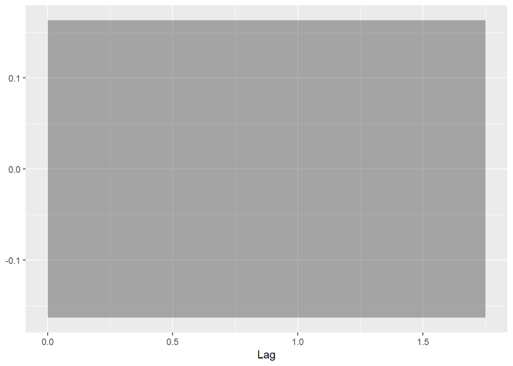

```r
d <- fortify(stats::acf(AirPassengers, plot = FALSE))
p <- ggplot(data = d, mapping = aes(x = Lag))
ggfortify:::plot_confint(p, data = d)
```

#### Description

Attach label to ggplot2::ggplot

#### Usage

```
plot_label(p, data, x = NULL, y = NULL, label = TRUE, label.label = "rownames", label.colour = NULL,
  label.alpha = NULL, label.size = NULL, label.angle = NULL, label.family = NULL,
  label.fontface = NULL, label.lineheight = NULL, label.hjust = NULL,
  label.vjust = NULL, label.repel = FALSE, label.show.legend = NA)
```

#### Arguments

- `P`: ggplot2::ggplot instance
- `data`: Data contains text label
- `x`: x coordinates for label
- `y`: y coordinates for label
- `label`: Logical value whether to display labels
- `label.label`: Column name used for label text
- `label.colour`: Colour for text labels
- `label.alpha`: Alpha for text labels
- `label.size`: Size for text labels
- `label.angle`: Angle for text labels
- `label.family`: Font family for text labels
- `label.fontface`: Fontface for text labels
- `label.lineheight`: Lineheight for text labels
- `label.hjust`: Horizontal adjustment for text labels
- `label.vjust`: Vertical adjustment for text labels
- `label.repel`: Logical flag indicating whether to use ggrepel, enabling this may take some time for plotting
- `label.show.legend`: Logical value indicating whether to show the legend of the text labels